# Week 5 - Assessment 1 - Part A

Dylan Rohan - a1844790

## Assessment 1: Part A - Practical 5

### Q1 - Plotting Panda Data Frames with Date indexes

Using the numpy modulke, below I introduce 6 diffferent series that are indexed by datetime values from 2016-01-01 until now with values randomly selected between 0 and 1. I then combine these series as columns in a DataFrame using the pandas module. The number of days between 1/1/2016 and now have been printed along with the first 30 rows of the DataFrame. I then proceed to create a dataframe of the cumulative sum of values in each column and print the first five rows as directed. The values have been presented in a line chart, and individually in subplots (using two different methods). Then in order to quickly plot the accumulative sum of each column, I used an area chart which combines all the values at each indexed point in time.

These charts reveal an obvious positive trend over time. As the y value increases by sum positive value from 0 to (but not including) 1, it's unsurpring. They all appear similar over large periods of time because the larger the domain, the more the trend will follow the average. In terms of the area chart, the gradient is mathematically related to it constituents and so it will be roughly six times the gradient of any individual series (as it took the accumulation of the six of themto generate it). I could have combined the collumns mathematically into a new 1D series, but this generates the same results mathematically and gives more information.

```python
# Question 1.1)
#Create six time series stored in a Pandas data frame:
#a) The data frame must have an index that is a range of dates from 2016-01-01 until today.
#b) Each column contains one set of random numbers in a range 0 to 1 (each column will have
#one random number for each date).

# Importing the numpy and pandas modules
import numpy as np
import pandas as pd

# Generating an index
date_time_index = pd.date_range('2016-01-01', 'now')
series_length = len(date_time_index)

# Creating six time series containing random values between [0,1) and indexing them with the timestamp:
timeseries_1 = pd.Series(np.random.rand(series_length), index = date_time_index)
timeseries_2 = pd.Series(np.random.rand(series_length), index = date_time_index)
timeseries_3 = pd.Series(np.random.rand(series_length), index = date_time_index)
timeseries_4 = pd.Series(np.random.rand(series_length), index = date_time_index)
timeseries_5 = pd.Series(np.random.rand(series_length), index = date_time_index)
timeseries_6 = pd.Series(np.random.rand(series_length), index = date_time_index)

# Compiling the 6 series into a DataFrame
time_frame = pd.DataFrame({"series 1":timeseries_1, "series 2":timeseries_2, "series 3":timeseries_3,
                           "series 4":timeseries_4, "series 5":timeseries_5, "series 6":timeseries_6})

###############################################################################################################
# Question 1.2) Calculate and print the number of days from 2016-01-01 until today.
print("The number of days since 01/01/2016 is: ", series_length)

#################################################################################################################
# Question 1.3) Show the first 30 rows of your data
time_frame.head(30)
```

```
The number of days since 01/01/2016 is:  2232
```

|  | series 1 | series 2 | series 3 | series 4 | series 5 | series 6 |
| --- | --- | --- | --- | --- | --- | --- |
| 2016-01-01 | 0.817086 | 0.667732 | 0.961048 | 0.207931 | 0.592027 | 0.748622 |
| 2016-01-02 | 0.797319 | 0.659980 | 0.499873 | 0.971835 | 0.910090 | 0.907516 |
| 2016-01-03 | 0.201128 | 0.106203 | 0.869994 | 0.486739 | 0.785355 | 0.449491 |
| 2016-01-04 | 0.350830 | 0.925289 | 0.208675 | 0.154203 | 0.158961 | 0.172964 |
| 2016-01-05 | 0.280306 | 0.543250 | 0.573741 | 0.560916 | 0.328049 | 0.353643 |
| 2016-01-06 | 0.872180 | 0.581664 | 0.770615 | 0.470172 | 0.057778 | 0.301886 |
| 2016-01-07 | 0.659527 | 0.486198 | 0.202259 | 0.773939 | 0.715973 | 0.797267 |
| 2016-01-08 | 0.562830 | 0.069303 | 0.839158 | 0.403340 | 0.372143 | 0.701023 |
| 2016-01-09 | 0.331529 | 0.131608 | 0.625745 | 0.614278 | 0.231430 | 0.511297 |
| 2016-01-10 | 0.673866 | 0.227104 | 0.098295 | 0.868154 | 0.447506 | 0.025100 |
| 2016-01-11 | 0.987427 | 0.501483 | 0.631874 | 0.123239 | 0.643205 | 0.228772 |
| 2016-01-12 | 0.144637 | 0.402816 | 0.241177 | 0.691606 | 0.893975 | 0.209870 |
| 2016-01-13 | 0.890385 | 0.423338 | 0.600580 | 0.344593 | 0.137729 | 0.566541 |
| 2016-01-14 | 0.727995 | 0.684714 | 0.433687 | 0.259947 | 0.561401 | 0.363198 |
| 2016-01-15 | 0.981735 | 0.943294 | 0.682123 | 0.322793 | 0.697708 | 0.141306 |
| 2016-01-16 | 0.266611 | 0.865248 | 0.904803 | 0.300294 | 0.473162 | 0.103286 |
| 2016-01-17 | 0.237772 | 0.117397 | 0.083106 | 0.840699 | 0.973254 | 0.841377 |
| 2016-01-18 | 0.213530 | 0.076119 | 0.601803 | 0.901450 | 0.202515 | 0.644020 |
| 2016-01-19 | 0.979782 | 0.039927 | 0.427249 | 0.276282 | 0.912226 | 0.347491 |
| 2016-01-20 | 0.789966 | 0.041755 | 0.440096 | 0.807591 | 0.931329 | 0.708613 |
| 2016-01-21 | 0.284705 | 0.838393 | 0.519990 | 0.167408 | 0.018565 | 0.808347 |
| 2016-01-22 | 0.364313 | 0.098711 | 0.940534 | 0.706782 | 0.061542 | 0.290902 |
| 2016-01-23 | 0.649649 | 0.536799 | 0.555769 | 0.909909 | 0.800662 | 0.338591 |
| 2016-01-24 | 0.256817 | 0.262986 | 0.824396 | 0.540071 | 0.059255 | 0.320398 |
| 2016-01-25 | 0.636374 | 0.489857 | 0.153161 | 0.381030 | 0.000824 | 0.434984 |
| 2016-01-26 | 0.450735 | 0.591821 | 0.376065 | 0.099420 | 0.062887 | 0.479948 |
| 2016-01-27 | 0.023870 | 0.577318 | 0.047994 | 0.093189 | 0.118997 | 0.122217 |
| 2016-01-28 | 0.356020 | 0.314185 | 0.351597 | 0.629698 | 0.017366 | 0.844646 |
| 2016-01-29 | 0.745251 | 0.527760 | 0.936702 | 0.720645 | 0.122029 | 0.842716 |
| 2016-01-30 | 0.097860 | 0.699033 | 0.973120 | 0.764261 | 0.142695 | 0.529550 |

```python
# Question 1.4) Calculate the cumulative sum of the Data frame
# Calculating the cumulative sums and presenting the first five rows
df_accumulate = time_frame.cumsum()
df_accumulate.head(5)
```

|  | series 1 | series 2 | series 3 | series 4 | series 5 | series 6 |
| --- | --- | --- | --- | --- | --- | --- |
| 2016-01-01 | 0.817086 | 0.667732 | 0.961048 | 0.207931 | 0.592027 | 0.748622 |
| 2016-01-02 | 1.614405 | 1.327712 | 1.460921 | 1.179766 | 1.502117 | 1.656137 |
| 2016-01-03 | 1.815533 | 1.433916 | 2.330915 | 1.666505 | 2.287472 | 2.105629 |
| 2016-01-04 | 2.166363 | 2.359205 | 2.539590 | 1.820708 | 2.446433 | 2.278593 |
| 2016-01-05 | 2.446669 | 2.902455 | 3.113331 | 2.381624 | 2.774482 | 2.632236 |

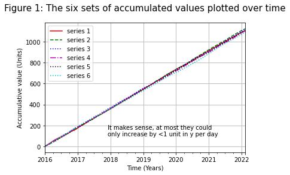

```python
# Question 1.5) Plot the six sets of row values of df_accumulate in a graph
# Ensuring all modules are loaded
import numpy as np
import pandas as pd
import matplotlib.pyplot as plt

%matplotlib inline
# magic function enabling plots to appear on notebook

# Plotting and styling the six different series
figure1 = plt.figure()
df_accumulate.plot(style =['r-','g--','b:','m-.','k:','c:'], grid = True)
plt.title("Figure 1: The six sets of accumulated values plotted over time", fontsize =15, pad = 20)
plt.xlabel("Time (Years)")
plt.ylabel("Accumulative value (Units)")
plt.text(17500,100, "It makes sense, at most they could\n"
         "only increase by <1 unit in y per day", fontsize = 10)
```

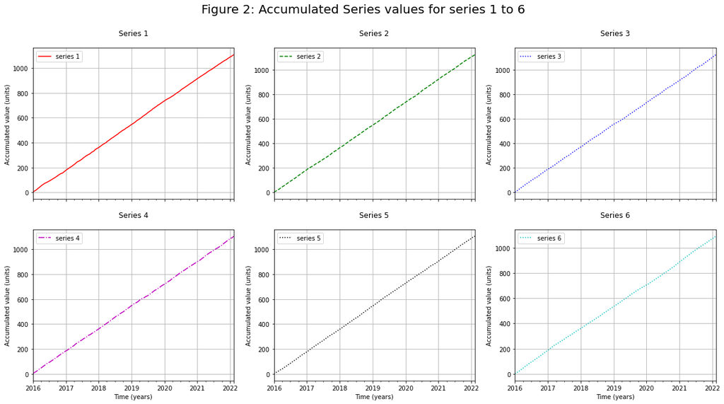

```python
# Question 1.6)
# Plot the six sets of row values of df_accumulate in separate graphs using subplots
# then plot the accumulate sum of each of the columns (random numbers).

# Ensuring all modules are loaded
import numpy as np
import pandas as pd
import matplotlib.pyplot as plt
%matplotlib inline
# Method 1 - plotting simple subplots
figure2 = plt.figure()
axs = df_accumulate.plot(subplots=True,
                         style= ['r-','g--','b:','m-.','k:','c:'],
                         fontsize=10,
                         layout =(2,3),
                         figsize = (20,10),
                         grid =True)

plt.setp(axs[:, :], xlabel='Time (years)')
plt.setp(axs[:, :], ylabel='Accumulated value (units)')
plt.suptitle("Figure 2: Accumulated Series values for series 1 to 6", fontsize=20)
axs[0, 0].set_title("Series 1", fontsize = 12, pad = 20)
axs[0, 1].set_title("Series 2", fontsize = 12, pad = 20)
axs[0, 2].set_title("Series 3", fontsize = 12, pad = 20)
axs[1, 0].set_title("Series 4", fontsize = 12, pad = 20)
axs[1, 1].set_title("Series 5", fontsize = 12, pad = 20)
axs[1, 2].set_title("Series 6", fontsize = 12, pad = 20)
```

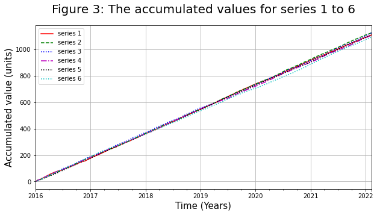

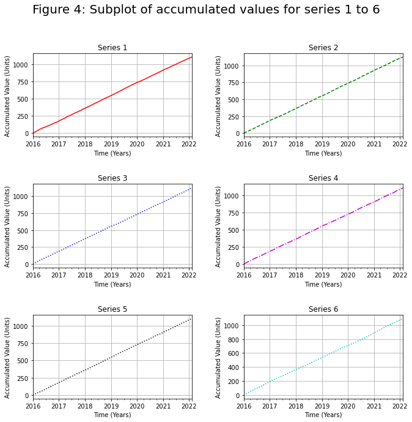

```python
# Method 2 - plotting more complex subplots
import pandas as pd
import numpy as np
import matplotlib.pyplot as plt

%matplotlib inline

number = np.arange(0., 5., 0.2)
legend = ['series 1','series 2','series 3', 'series 4', 'series 5', 'series 6']
figure3 = plt.figure()
plots = df_accumulate.plot(style = ['r-','g--','b:','m-.','k:','c:'],
                           fontsize = 10,
                           figsize=(10,5))
plots.legend(legend, loc='upper left')
plt.grid(True)
plt.xlabel("Time (Years)", fontsize =15)
plt.ylabel("Accumulated value (units)", fontsize =15)
plt.title("Figure 3: The accumulated values for series 1 to 6", pad =20, fontsize=20)

figure4 = plt.figure()
rows = 3
columns =2
style =[0, 'r-','g--','b:','m-.','k:','c:']
fig, plots = plt.subplots(rows, columns)

counter=1
for r in range(rows):
    for c in range(columns):
        df_accumulate["series "+str(counter)].plot(ax=plots[r,c],
                                                   figsize=(10,10),
                                                   title = "Series "+str(counter),
                                                   style= style[0+counter],
                                                   xlabel="Time (Years)",
                                                   ylabel= "Accumulated Value (Units)",
                                                   grid =True)
        counter= counter + 1
plt.suptitle("Figure 4: Subplot of accumulated values for series 1 to 6", fontsize= 20)
fig.tight_layout(pad=3)
```

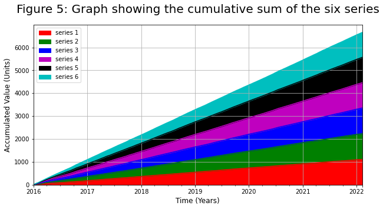

```python
# Plotting the accumulative sum of all collumns with an area chart
figure5 = plt.figure()
df_accumulate.plot.area(figsize=(10,5),
                       grid = True,
                        fontsize=10,
                       style = ['r','g','b','m','k','c'])
plt.title('Figure 5: Graph showing the cumulative sum of the six series',
          fontsize = 20,
          pad = 20)
plt.xlabel("Time (Years)", fontsize = 12)
plt.ylabel("Accumulated Value (Units)", fontsize =12)
```

### Q2- Manipulating mental health data

Below I have used the Pandas module to read the CSV and write it as a DataFrame. The first five rows are presented. The DataFrame is then ammended so that the "Timestamp" column contained values of a datetime type. The shape of the DataFrame is then checked and found to be 1259 rows by 27 columns. The data is then checked for irregularities in the Age attribute; removing subjects younger than 1 and older than 99. Two methods have been provided to achieve the ammendments required. The maximum, mean, and minimum values of the Age attribute have been printed.

```python
# Question 2.a) Print the first five rows to show that the data has loaded and print the total number of rows
# Ensuring all modules are loaded
import csv
import numpy as np
import pandas as pd

# converting strings to datetimes and checking the first five rows
data = pd.read_csv("survey.csv")
data["Timestamp"] =  pd.to_datetime(data["Timestamp"])
data.head(5)
```

|  | Timestamp | Age | Gender | Country | state | self_employed | family_history | treatment | work_interfere | no_employees | ... | leave | mental_health_consequence | phys_health_consequence | coworkers | supervisor | mental_health_interview | phys_health_interview | mental_vs_physical | obs_consequence | comments |
| --- | --- | --- | --- | --- | --- | --- | --- | --- | --- | --- | --- | --- | --- | --- | --- | --- | --- | --- | --- | --- | --- |
| 0 | 2014-08-27 11:29:31 | 37 | Female | United States | IL | NaN | No | Yes | Often | 6-25 | ... | Somewhat easy | No | No | Some of them | Yes | No | Maybe | Yes | No | NaN |
| 1 | 2014-08-27 11:29:37 | 44 | M | United States | IN | NaN | No | No | Rarely | More than 1000 | ... | Don't know | Maybe | No | No | No | No | No | Don't know | No | NaN |
| 2 | 2014-08-27 11:29:44 | 32 | Male | Canada | NaN | NaN | No | No | Rarely | 6-25 | ... | Somewhat difficult | No | No | Yes | Yes | Yes | Yes | No | No | NaN |
| 3 | 2014-08-27 11:29:46 | 31 | Male | United Kingdom | NaN | NaN | Yes | Yes | Often | 26-100 | ... | Somewhat difficult | Yes | Yes | Some of them | No | Maybe | Maybe | No | Yes | NaN |
| 4 | 2014-08-27 11:30:22 | 31 | Male | United States | TX | NaN | No | No | Never | 100-500 | ... | Don't know | No | No | Some of them | Yes | Yes | Yes | Don't know | No | NaN |

5 rows × 27 columns

```python
# Ensuring the values are properly typed
print(data.dtypes)
print()
# Checking the shape of the data frame
print("The DataFrame has a shape of 1259 rows and 27 columns:", data.shape)
```

```
Timestamp                    datetime64[ns]
Age                                   int64
Gender                               object
Country                              object
state                                object
self_employed                        object
family_history                       object
treatment                            object
work_interfere                       object
no_employees                         object
remote_work                          object
tech_company                         object
benefits                             object
care_options                         object
wellness_program                     object
seek_help                            object
anonymity                            object
leave                                object
mental_health_consequence            object
phys_health_consequence              object
coworkers                            object
supervisor                           object
mental_health_interview              object
phys_health_interview                object
mental_vs_physical                   object
obs_consequence                      object
comments                             object
dtype: object

The DataFrame has a shape of 1259 rows and 27 columns: (1259, 27)
```

```python
# Finding rows that have Ages lower than 1 and  higher than 99
data[(data.Age <1) | (data.Age >99)]
```

|  | Timestamp | Age | Gender | Country | state | self_employed | family_history | treatment | work_interfere | no_employees | ... | leave | mental_health_consequence | phys_health_consequence | coworkers | supervisor | mental_health_interview | phys_health_interview | mental_vs_physical | obs_consequence | comments |
| --- | --- | --- | --- | --- | --- | --- | --- | --- | --- | --- | --- | --- | --- | --- | --- | --- | --- | --- | --- | --- | --- |
| 143 | 2014-08-27 12:39:14 | -29 | Male | United States | MN | No | No | No | NaN | More than 1000 | ... | Don't know | No | No | Some of them | Yes | No | No | Don't know | No | NaN |
| 364 | 2014-08-27 15:05:21 | 329 | Male | United States | OH | No | No | Yes | Often | 6-25 | ... | Don't know | Maybe | No | Some of them | No | No | No | No | No | NaN |
| 390 | 2014-08-27 15:24:47 | 99999999999 | All | Zimbabwe | NaN | Yes | Yes | Yes | Often | 1-5 | ... | Very difficult | Yes | Yes | No | No | Yes | No | No | Yes | NaN |
| 715 | 2014-08-28 10:07:53 | -1726 | male | United Kingdom | NaN | No | No | Yes | Sometimes | 26-100 | ... | Somewhat difficult | Yes | No | No | No | No | Maybe | Don't know | No | NaN |
| 1127 | 2014-08-30 20:55:11 | -1 | p | United States | AL | Yes | Yes | Yes | Often | 1-5 | ... | Very easy | Yes | Yes | Yes | Yes | Yes | Yes | Yes | Yes | password: testered |

5 rows × 27 columns

```python
# Question 2.b) Drop these rows
# Method 1 - Dropping irregular data subjects by index
row_removal_list =[143, 715, 1127, 364, 390]
new_data = data.drop(row_removal_list, axis = 0)
print(new_data.shape)
print("We have removed 5 rows in total (from 1259 to 1254), but the 27 columns are all still accounted for.")
```

```
(1254, 27)
We have removed 5 rows in total (from 1259 to 1254), but the 27 columns are all still accounted for.
```

```python
# Method 2 - dropping irregular data subjects by condition
data.drop(data[data.Age < 1].index, inplace=True)
data.drop(data[data.Age >99].index, inplace =True)
print("Once again we can see there are now 27 columns and 1254 rows:", data.shape)
```

```
Once again we can see there are now 27 columns and 1254 rows: (1254, 27)
```

```python
# Question 2.c) Print the maximum, mean and minimum age values in your data.
# printing the max, mean and min values of the Age attribute with max(), mean() and min()
print("Maximum Age value in data: ",data.Age.max(), "years")
print("Mean Age value in data: ",round(data.Age.mean()), "years")
print("Minimum Age value in data: ",data.Age.min(), "years")
```

```
Maximum Age value in data:  72 years
Mean Age value in data:  32 years
Minimum Age value in data:  5 years
```

### Q3 - Plotting Mental Health Data

Below I have taken the survey data and created two sub groups; the group that has a family history and the group that doesn not. I then plot this data on a chart of side-by side boxplots. I also extended the task, electing to plot these two sets of data on individual histograms to better prepare for assignment 2 (having completed this in week 3). I comb through the data again, this time for instances of subjects indicating their employer had brought up mental health in the context of a mental wellness program. Using this data set I created a horizontal bar chart that counts the frequency of affirmative responses and presents them as geographically independent groups.

To me this indicates that a persons age does not play a significant role in wether or not they have a family history nor how honestly they answer the question.

As for the horizontal bar chart, the united states had the most instances of subjects reporting their employer had mentioned mental health in the context of a mental wellness program. While this is good to see, it does not necessarily indicate the united states are ahead of the curve. Infact if we look at the data this represents only 22.2% of American participants, which is great compared to France's 15.4%, but no so good compared to Australia's 38.0%. It's important to understand what the data does and does not represent, this chart is misleading.

```python
# Question 3.a)
# Creating a dataframe containing only instances of no family history
data.head(5)
# No family history
no_history = data[data["family_history"]=="No"]
print("Maximum Age for no_history population: ",no_history.Age.max(), "years")
print("Mean Age for no_history population",round(no_history.Age.mean()), "years")
print("Minimum Age for no_history population",no_history.Age.min(), "years")
no_history.head(5)
```

```
Maximum Age for no_history population:  65 years
Mean Age for no_history population 32 years
Minimum Age for no_history population 5 years
```

|  | Timestamp | Age | Gender | Country | state | self_employed | family_history | treatment | work_interfere | no_employees | ... | leave | mental_health_consequence | phys_health_consequence | coworkers | supervisor | mental_health_interview | phys_health_interview | mental_vs_physical | obs_consequence | comments |
| --- | --- | --- | --- | --- | --- | --- | --- | --- | --- | --- | --- | --- | --- | --- | --- | --- | --- | --- | --- | --- | --- |
| 0 | 2014-08-27 11:29:31 | 37 | Female | United States | IL | NaN | No | Yes | Often | 6-25 | ... | Somewhat easy | No | No | Some of them | Yes | No | Maybe | Yes | No | NaN |
| 1 | 2014-08-27 11:29:37 | 44 | M | United States | IN | NaN | No | No | Rarely | More than 1000 | ... | Don't know | Maybe | No | No | No | No | No | Don't know | No | NaN |
| 2 | 2014-08-27 11:29:44 | 32 | Male | Canada | NaN | NaN | No | No | Rarely | 6-25 | ... | Somewhat difficult | No | No | Yes | Yes | Yes | Yes | No | No | NaN |
| 4 | 2014-08-27 11:30:22 | 31 | Male | United States | TX | NaN | No | No | Never | 100-500 | ... | Don't know | No | No | Some of them | Yes | Yes | Yes | Don't know | No | NaN |
| 7 | 2014-08-27 11:32:05 | 39 | M | Canada | NaN | NaN | No | No | Never | 1-5 | ... | Don't know | No | No | No | No | No | No | No | No | NaN |

5 rows × 27 columns

```python
# Creating a dataframe containing only instances with family history
data.head(5)
# Have a family history
Yes_history = data[data["family_history"]=="Yes"]
print("Maximum Age for Yes_history population: ",Yes_history.Age.max(), "years")
print("Mean Age for Yes_history population",round(Yes_history.Age.mean()), "years")
print("Minimum Age for Yes_history population",Yes_history.Age.min(), "years")
Yes_history.head(5)
```

```
Maximum Age for Yes_history population:  72 years
Mean Age for Yes_history population 32 years
Minimum Age for Yes_history population 8 years
```

|  | Timestamp | Age | Gender | Country | state | self_employed | family_history | treatment | work_interfere | no_employees | ... | leave | mental_health_consequence | phys_health_consequence | coworkers | supervisor | mental_health_interview | phys_health_interview | mental_vs_physical | obs_consequence | comments |
| --- | --- | --- | --- | --- | --- | --- | --- | --- | --- | --- | --- | --- | --- | --- | --- | --- | --- | --- | --- | --- | --- |
| 3 | 2014-08-27 11:29:46 | 31 | Male | United Kingdom | NaN | NaN | Yes | Yes | Often | 26-100 | ... | Somewhat difficult | Yes | Yes | Some of them | No | Maybe | Maybe | No | Yes | NaN |
| 5 | 2014-08-27 11:31:22 | 33 | Male | United States | TN | NaN | Yes | No | Sometimes | 6-25 | ... | Don't know | No | No | Yes | Yes | No | Maybe | Don't know | No | NaN |
| 6 | 2014-08-27 11:31:50 | 35 | Female | United States | MI | NaN | Yes | Yes | Sometimes | 1-5 | ... | Somewhat difficult | Maybe | Maybe | Some of them | No | No | No | Don't know | No | NaN |
| 8 | 2014-08-27 11:32:39 | 42 | Female | United States | IL | NaN | Yes | Yes | Sometimes | 100-500 | ... | Very difficult | Maybe | No | Yes | Yes | No | Maybe | No | No | NaN |
| 12 | 2014-08-27 11:33:23 | 42 | female | United States | CA | NaN | Yes | Yes | Sometimes | 26-100 | ... | Somewhat difficult | Yes | Yes | Yes | Yes | Maybe | Maybe | No | Yes | NaN |

5 rows × 27 columns

[figure not shown]

```python
# Ensuring all modules are loaded
import numpy as np
import pandas as pd
import matplotlib.pyplot as plt

boxplot = [no_history.Age, Yes_history.Age]
%matplotlib inline
outliers = dict(markerfacecolor='turquoise', marker='o')
figure6 = plt.figure(figsize= (10,7.5))
plt.boxplot(boxplot,
            flierprops = outliers,
           notch = True,
           medianprops = dict(linestyle='-.', linewidth=2.5, color='firebrick'),
           showmeans = True,
            meanprops = dict(marker='o', markeredgecolor='black', markerfacecolor='white'))

plt.title("Figure 6: Age of Subjects with no family history\n of mental illness", fontsize = 18)
plt.ylabel("Age of participant (Years)", fontsize=15)
plt.xticks([1, 2], ['No', 'Yes'], fontsize = 15)
plt.xlabel("Have you sought treatment for a mental health condition?", fontsize = 15)

plt.grid(True)
```

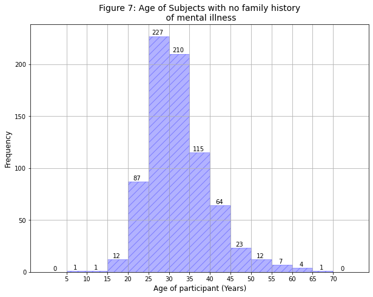

```python
#Bonus chart!
# Ensuring all modules are loaded
import numpy as np
import pandas as pd
import matplotlib.pyplot as plt

%matplotlib inline
# preparing x-ticks to match bin widths
x = [0,5,10,15,20,25,30,35,40,45,50,55,60,65,70,75]

# Plotting a histogram that gives meaningful representation of the age of participants with no family history
figure7 = plt.figure(figsize= (10,7.5))
freq, bins, patches = plt.hist(no_history.Age, bins = x, color = "b", ec ='b', hatch="//", alpha = 0.3)
plt.title("Figure 7: Age of Subjects with no family history\n of mental illness", fontsize = 14)
plt.xlabel("Age of participant (Years)", fontsize=12)
plt.ylabel("Frequency", fontsize=12)
plt.xticks(range(5,75,5))
plt.grid(True)

n = 0
for fr, x, patch in zip(freq, bins, patches):
    height = int(freq[n])
    plt.annotate("{}".format(height),
               xy = (x, height),             # top left corner of the histogram bar
               xytext = (15,0.5),             # offsetting label position above its bar
               textcoords = "offset points", # Offset (in points) from the *xy* value
               ha = 'center', va = 'bottom'
               )
    n = n+1
```

[figure not shown]

```python
# Bonus chart!
# Ensuring all modules are loaded
import numpy as np
import pandas as pd
import matplotlib.pyplot as plt
%matplotlib inline
# preparing ticks again to match bin widths
x = [0,5,10,15,20,25,30,35,40,45,50,55,60,65,70,75]

# Plotting a histogram that gives meaningful representation of the age of participants that have family history
figure8 = plt.figure(figsize= (10,7.5))
freq, bins, patches = plt.hist(Yes_history.Age, bins = x, color = "r", ec ='r', hatch ="xx", alpha = 0.3)
plt.title("Figure 8: Age of Subjects with no family history\n of mental illness", fontsize = 14)
plt.xlabel("Age of participant (Years)", fontsize=12)
plt.ylabel("Frequency", fontsize=12)
plt.xticks(range(5,75,5))
plt.grid(True)

n = 0
for fr, x, patch in zip(freq, bins, patches):
    height = int(freq[n])
    plt.annotate("{}".format(height),
               xy = (x, height),             # top left corner of the histogram bar
               xytext = (15,0.5),             # offsetting label position above its bar
               textcoords = "offset points", # Offset (in points) from the *xy* value
               ha = 'center', va = 'bottom'
               )
    n = n+1
```

```python
# Question 3.b)
# Collecting the participants that answered yes to the Wellness program question
data.head(5)
yes_wellness_program = data[data["wellness_program"]=="Yes"]
yes_wellness_program = yes_wellness_program.sort_values("Country", ascending = False)
yes_wellness_program.head(5)
```

|  | Timestamp | Age | Gender | Country | state | self_employed | family_history | treatment | work_interfere | no_employees | ... | leave | mental_health_consequence | phys_health_consequence | coworkers | supervisor | mental_health_interview | phys_health_interview | mental_vs_physical | obs_consequence | comments |
| --- | --- | --- | --- | --- | --- | --- | --- | --- | --- | --- | --- | --- | --- | --- | --- | --- | --- | --- | --- | --- | --- |
| 18 | 2014-08-27 11:34:53 | 46 | male | United States | MD | Yes | Yes | No | Sometimes | 1-5 | ... | Very easy | No | No | Yes | Yes | No | Yes | Yes | Yes | NaN |
| 843 | 2014-08-28 16:55:07 | 35 | Male | United States | CA | No | No | No | Sometimes | More than 1000 | ... | Don't know | Maybe | No | Some of them | No | No | No | Don't know | No | NaN |
| 766 | 2014-08-28 11:50:06 | 33 | Female | United States | AZ | Yes | Yes | Yes | Sometimes | 1-5 | ... | Somewhat easy | Maybe | Yes | Some of them | No | No | No | No | No | NaN |
| 785 | 2014-08-28 12:30:20 | 25 | Male | United States | NE | No | Yes | Yes | Sometimes | More than 1000 | ... | Don't know | Maybe | No | Some of them | Some of them | No | No | No | Yes | NaN |
| 800 | 2014-08-28 13:39:12 | 29 | Male | United States | MD | No | No | No | Never | 100-500 | ... | Very easy | Yes | Maybe | Yes | Yes | No | Maybe | Don't know | No | NaN |

5 rows × 27 columns

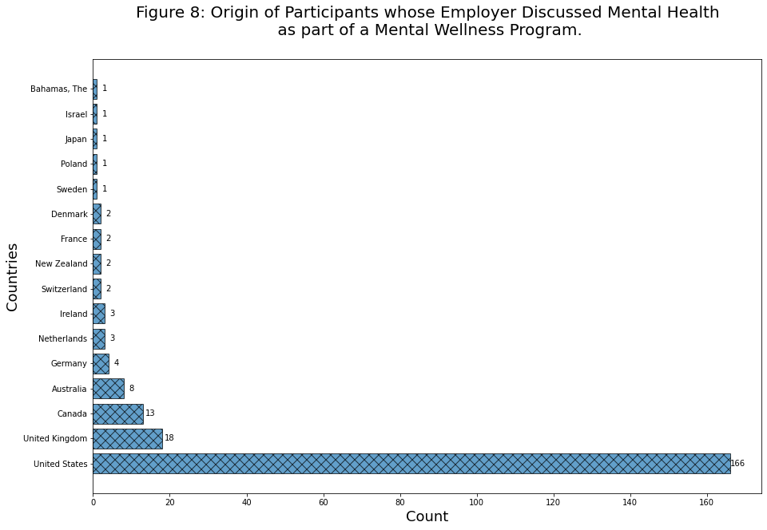

```python
# Creating a dataframe with countries indexed to their frequency in the yes_wellnesss_program data
country_frequency = yes_wellness_program["Country"].value_counts()
x_y =pd.DataFrame(country_frequency)
x_y.columns=["Frequency"]

# Plotting a horizontal bar chart and styling it
#std1=[could set standard errors bars by imputting error list here]
figure8 = plt.figure(figsize=(15,10)) #setting figure size
chart = plt.barh(x_y.index,
         x_y["Frequency"],
         #xerr=std1
         #error_kw={'ecolor':'0.8','capsize':20},
         alpha  = 0.7,
         label = 'First',
         hatch = 'XX',
        edgecolor="black")

plt.title("Figure 8: Origin of Participants whose "
          "Employer Discussed Mental Health\n as part of a Mental Wellness Program.", fontsize=20, pad=30)
plt.ylabel("Countries", fontsize=18)
plt.xlabel("Count", fontsize=18)
for bar in chart:
        width = bar.get_width()
        plt.text(2 + bar.get_width(), bar.get_y()+0.5*bar.get_height(),
                 '%d' % int(width),
                 ha='center', va='center')
```

```python
print(len(data[data["Country"]=="Australia"]))
166/748*100 #america
2/13*100 #France
8/21*100 #Australia
```

```
21
```

```
38.095238095238095
```

### Question 4 - Cleaning Data

Below I have cleaned the responses to the question of Gender into three categories. I then create dataframes for males and females that indicate the number or people that have sought treatment for mental illness in both cases. These data sets are then used to create pie charts.

A larger portion of the female population were found to have sought treatment than that of the male population. The population as a whole was found to have 50% of subjects reporting they had sought treatment. So although males appear less likely to seek treatment, the entire population has an issue seeking support. In general, it seemed those who did not identify as Cis-gendered were most likley to seek treatment. However, the population of subjects was also heavily male dominant (988 of 1254). It is difficult to say how reliable these results are when you compare a population of 247 women to one of 988 men, not to mention the 19 subjects recorded as other.

```python
# Question 4.a)
# Unifying the responses to Gender into three categories: Male, Female, Other
identified_male = ['male','m', 'M', 'Make', 'Man', "Mail", "Malr",'msle','Mal',
                   'maile', "Male", 'Cis Male', 'Male (CIS)','cis male', 'Cis man', "Male ",'Cis Man','Guy (-ish) ^_^']
identified_female = ['female','F','f','Female','Femake','woman','femail','Woman',
                     'Cis Female', 'cis-female/femme', "Female (cis)", "Female "]
identified_other = ['Male-ish', 'Trans-female', 'something kinda male?', 'queer/she/they',
                    'non-binary', 'Nah', 'Enby', 'fluid', 'Genderqueer', 'Androgyne',
                    'Agender', 'male leaning androgynous', 'Trans woman', 'Neuter',
                    'Female (trans)', 'queer', 'A little about you', 'ostensibly male, unsure what that really means']

for value in identified_male:
    data.loc[(data.Gender == value,'Gender')]='Male'

for value in identified_female:
    data.loc[(data.Gender == value,'Gender')]='Female'

for value in identified_other:
    data.loc[(data.Gender == value,'Gender')]='other'

# I did notice another two options not listed: "Male " and "Female "
print(data.Gender.unique())
print(data.treatment.unique())
print("number of people that sought treatment: ", len(data[data["treatment"]=="Yes"]))
print("number of people that responded with 'Yes' or 'No': ", len(data[data["treatment"]=="Yes"])+len(data[data["treatment"]=="No"]))
print("Proportion of affirmative responses: ", round(633/1254*100))
print("number of females", len(data[data["Gender"]=="Female"]))
print("number of males", len(data[data["Gender"]=="Male"]))
print("number of other", len(data[data["Gender"]=="other"]))
```

```
['Female' 'Male' 'other']
['Yes' 'No']
number of people that sought treatment:  633
number of people that responded with 'Yes' or 'No':  1254
Proportion of affirmative responses:  50
number of females 247
number of males 988
number of other 19
```

```
     count
No     540
Yes    448
```

```
(-1.215862326433846,
 1.1309605391236792,
 -1.126060923236594,
 1.1012409963445813)
```

[figure not shown]

```python
# Question 4.b)
# Finding the proportion of Males that have sought/not sought treatment for a mental health condition
males_only = data[data["Gender"]=="Male"]
treatment = males_only["treatment"].value_counts()
treatment_df = pd.DataFrame(treatment)
treatment_df.columns=["count"]
print(treatment_df)

# Creating and styling a Pie chart that shows how males responded to the question of treatment
fontsize = {'fontsize':12}
labels = ['Sought treatment', "Didn't seek treetment"]
values = [540, 448]
colors = ['aqua','r']
explode = [0.1,0]
figure10 = plt.figure()
plt.pie(values, labels=labels,
        colors = colors,
        explode = explode,
        startangle = 90,
        shadow = True,
        autopct = '%1.1f%%',
        wedgeprops={'alpha':0.5},
       textprops=fontsize)

plt.title("Figure 10: How males responded to the\n question of seeking treatment", fontsize = 15)
plt.axis('equal')
```

```
     count
Yes    170
No      77
```

```
(-1.133214460677117, 1.5447201359063294, -1.114600875057519, 1.406617700440394)
```

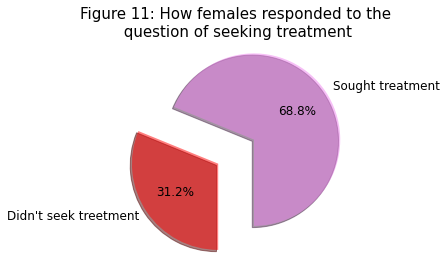

```python
# Finding the proportion of Males that have sought/not sought treatment for a mental health condition
females_only = data[data["Gender"]=="Female"]
treatment2 = females_only["treatment"].value_counts()
treatment2_df = pd.DataFrame(treatment2)
treatment2_df.columns=["count"]
print(treatment2_df)


# Creating and styling a Pie chart that shows how females responded to the question of treatment
fontsize = {'fontsize':12}
labels = ['Sought treatment', "Didn't seek treetment"]
values = [170, 77]
colors = ['violet','r']
explode = [0.5,0]
figure11 = plt.figure()
plt.pie(values, labels=labels,
        colors = colors,
        explode = explode,
        startangle = -90,
        shadow = True,
        autopct = '%1.1f%%',
        wedgeprops={'alpha':0.5},
       textprops=fontsize)

plt.title("Figure 11: How females responded to the\n question of seeking treatment", fontsize = 15)
plt.axis('equal')
```

```
     count
Yes     15
No       4
```

```
(-1.0833218713737711,
 1.4229544062545756,
 -1.1198998020750626,
 1.5178949271707123)
```

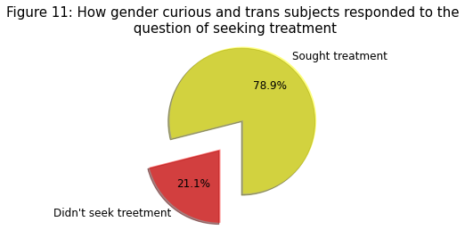

```python
# Finding the proportion of Males that have sought/not sought treatment for a mental health condition
other_only = data[data["Gender"]=="other"]
treatment3 = other_only["treatment"].value_counts()
treatment3_df = pd.DataFrame(treatment3)
treatment3_df.columns=["count"]
print(treatment3_df)


# Creating and styling a Pie chart that shows how females responded to the question of treatment
fontsize = {'fontsize':12}
labels = ['Sought treatment', "Didn't seek treetment"]
values = [15, 4]
colors = ['yellow','r']
explode = [0.5,0]
figure11 = plt.figure()
plt.pie(values, labels=labels,
        colors = colors,
        explode = explode,
        startangle = -90,
        shadow = True,
        autopct = '%1.1f%%',
        wedgeprops={'alpha':0.5},
       textprops=fontsize)

plt.title("Figure 11: How gender curious and trans subjects responded to the\n question of seeking treatment", fontsize = 15)
plt.axis('equal')
```